# Predicting median income in USA with the usage of spatially lagged linear model

2024-06-06

```r
rm(list=ls())
```

## Libraries

```r
library(tidyverse)
library(janitor)
library(skimr)
library(sf)
library(sfdep)
library(spdep)
library(spatial)
library(spatialreg)
library(ggmap)
library(mapproj)
library(maps)
library(readxl)
library(scales)
library(gridExtra)
library(cowplot)
library(png)
library(ggpubr)
```

## Reading the data

```r
geo_data <- st_read("us_states_coordinates.json")
invalid_geometries <- geo_data %>% filter(!st_is_valid(.))
invalid_geometries
```

```
## Simple feature collection with 3 features and 3 fields
## Geometry type: MULTIPOLYGON
## Dimension:     XY
## Bounding box:  xmin: -188.9049 ymin: 38.42427 xmax: -74.69661 ymax: 71.35163
## Geodetic CRS:  WGS 84
##   id         name density                       geometry
## 1 02       Alaska   1.264 MULTIPOLYGON (((-131.602 55...
## 2 39         Ohio 281.900 MULTIPOLYGON (((-80.5186 41...
## 3 42 Pennsylvania 284.300 MULTIPOLYGON (((-79.76278 4...
```

```r
# Attempt to make invalid geometries valid
geo_data <- geo_data %>% mutate(geometry = st_make_valid(geometry))
```

```r
geo_data$name
```

```
##  [1] "Alabama"              "Alaska"               "Arizona"
##  [4] "Arkansas"             "California"           "Colorado"
##  [7] "Connecticut"          "Delaware"             "District of Columbia"
## [10] "Florida"              "Georgia"              "Hawaii"
## [13] "Idaho"                "Illinois"             "Indiana"
## [16] "Iowa"                 "Kansas"               "Kentucky"
## [19] "Louisiana"            "Maine"                "Maryland"
## [22] "Massachusetts"        "Michigan"             "Minnesota"
## [25] "Mississippi"          "Missouri"             "Montana"
## [28] "Nebraska"             "Nevada"               "New Hampshire"
## [31] "New Jersey"           "New Mexico"           "New York"
## [34] "North Carolina"       "North Dakota"         "Ohio"
## [37] "Oklahoma"             "Oregon"               "Pennsylvania"
## [40] "Rhode Island"         "South Carolina"       "South Dakota"
## [43] "Tennessee"            "Texas"                "Utah"
## [46] "Vermont"              "Virginia"             "Washington"
## [49] "West Virginia"        "Wisconsin"            "Wyoming"
## [52] "Puerto Rico"
```

```r
income_data <- read_excel("us_states_income.xlsx")
```

```r
urban_data <- read_excel("us_urbanization.xlsx")
density_data <- read_excel("us_density.xlsx")
age_data <- read_excel("us_median_age.xlsx")
degree_data <- read_excel("us_states_bachelor.xlsx")
```

```r
urban_data <- urban_data %>%
  mutate(urbanization = as.numeric(urbanization))

density_data <- density_data %>%
  mutate(population_density = as.numeric(population_density))

age_data <- age_data %>%
  mutate(median_age = as.numeric(median_age))

degree_data <- degree_data %>%
  mutate(population_over_25 = as.numeric(population_over_25))
```

```r
income_data <- income_data %>%
  inner_join(urban_data,by="us_state") %>%
  inner_join(density_data,by="us_state") %>%
  inner_join(age_data,by="us_state") %>%
  inner_join(degree_data,by="us_state")
```

```r
income_data <- income_data %>%
  rename("name"="us_state")

income_data <- geo_data %>%
  inner_join(income_data,by="name")
```

```r
class(income_data)
```

```
## [1] "sf"         "data.frame"
```

## Creating neighbour list object

```r
nb <- st_contiguity(income_data)
```

```r
nb
```

```
## Neighbour list object:
## Number of regions: 46
## Number of nonzero links: 202
## Percentage nonzero weights: 9.546314
## Average number of links: 4.391304
```

```r
nb[1:3] #first observation has neighbors with observation 8,9,22,38 and so on..
```

```
## [[1]]
## [1]  8  9 22 38
##
## [[2]]
## [1]  4  5 26 29 40
##
## [[3]]
## [1] 16 22 23 33 38 39
```

## Compute spatial weights (row-standarized)

#### Row-standarization means that each element in the weight matrix gets divided by the sum within each row

```r
wt <- st_weights(nb) #spatial weights (row standardized)
```

```r
wt
```

```
## [[1]]
## [1] 0.25 0.25 0.25 0.25
##
## [[2]]
## [1] 0.2 0.2 0.2 0.2 0.2
##
## [[3]]
## [1] 0.1666667 0.1666667 0.1666667 0.1666667 0.1666667 0.1666667
##
## [[4]]
## [1] 0.3333333 0.3333333 0.3333333
##
## [[5]]
## [1] 0.1428571 0.1428571 0.1428571 0.1428571 0.1428571 0.1428571 0.1428571
##
## [[6]]
## [1] 0.5 0.5
##
## [[7]]
## [1] 0.3333333 0.3333333 0.3333333
##
## [[8]]
## [1] 0.5 0.5
##
## [[9]]
## [1] 0.25 0.25 0.25 0.25
##
## [[10]]
## [1] 0.1666667 0.1666667 0.1666667 0.1666667 0.1666667 0.1666667
##
## [[11]]
## [1] 0.2 0.2 0.2 0.2 0.2
##
## [[12]]
## [1] 0.25 0.25 0.25 0.25
##
## [[13]]
## [1] 0.1666667 0.1666667 0.1666667 0.1666667 0.1666667 0.1666667
##
## [[14]]
```

[output cut: 91 more lines]

```
##
## [[45]]
## [1] 0.25 0.25 0.25 0.25
##
## [[46]]
## [1] 0.1666667 0.1666667 0.1666667 0.1666667 0.1666667 0.1666667
##
## attr(,"mode")
## [1] "binary"
## attr(,"W")
## [1] TRUE
## attr(,"comp")
## attr(,"comp")$d
##  [1] 4 5 6 3 7 2 3 2 4 6 5 4 6 4 7 3 1 4 4 3 4 4 8 4 6 5 3 3 5 5 3 5 6 4 6 1 6 7
## [39] 4 6 3 4 2 5 4 6
```

## Spatial lag

#### Spatial lag is computed as sum of multiplication of each neighbor row-standarized weight and its value for the variable of interest.

```r
x <- income_data$median_income
```

```r
st_lag(x,nb,wt)
```

```
##  [1] 61747.50 79956.00 63653.33 77520.00 73371.43 84730.00 90916.67 63770.00
##  [9] 63107.50 81735.00 69416.00 67602.50 76466.67 75812.50 70014.29 59076.67
## [17] 84970.00 72647.50 80950.00 70293.33 73887.50 59400.00 68052.50 72892.50
## [25] 75180.00 82782.00 80300.00 76290.00 79452.00 84204.00 76850.00 63914.00
## [33] 69921.67 79910.00 79530.00 67630.00 78310.00 63242.86 58042.50 72966.67
## [41] 84810.00 70480.00 79680.00 77796.00 78430.00 79471.67
```

#### For example, let’s take a look on the spatial lag for the first observation in the data set:

#### The first observation is Alabama, which has neighbors with indexes 8, 9, 22, 38 which are:

- Florida
- Georgia
- Mississippi
- Tennessee

#### Since Alabama has 4 neighbors, all of them will have the weight of 0.25 in the weight matrix

#### These are the median incomes values for the neighbors:

- Florida 65370
- Georgia 67630
- Mississippi 48610
- Tennessee 65380

#### To calculate the spatial lag for Alabama, we will have to multiply the weights (all are equal to 0.25) with the median incomes

```r
ij <- nb[[1]]
wij <- wt[[1]]
xij <- x[ij]
```

```r
ij #Neighbors indexes
```

```
## [1]  8  9 22 38
```

```r
wij #Weights
```

```
## [1] 0.25 0.25 0.25 0.25
```

```r
xij #Median incomes in Florida, Georgia, Mississippi, Tennessee respectively
```

```
## [1] 65370 67630 48610 65380
```

```r
as.tibble(income_data) %>%
  filter(name %in% c("Florida","Georgia","Mississippi","Tennessee")) %>%
  select(c(name,median_income))
```

```
## # A tibble: 4 × 2
##   name        median_income
##   <chr>               <dbl>
## 1 Florida             65370
## 2 Georgia             67630
## 3 Mississippi         48610
## 4 Tennessee           65380
```

#### First spatial lag value

```r
sum(xij*wij) #Spatial lag value for Alabama
```

```
## [1] 61747.5
```

## Creating a data frame with neighbors, weights and spatial lag values

```r
income_lags <- income_data %>%
  transmute(nb=st_contiguity(geometry),
            wt = st_weights(nb),
            income_lag = st_lag(median_income,nb,wt))
```

```r
income_lags %>%
  as_tibble() %>%
  head()
```

```
## # A tibble: 6 × 4
##   nb        wt        income_lag                                        geometry
##   <nb>      <list>         <dbl>                              <MULTIPOLYGON [°]>
## 1 <int [4]> <dbl [4]>     61748. (((-88.20274 34.9957, -88.09868 34.89164, -88.…
## 2 <int [5]> <dbl [5]>     79956  (((-110.4994 37.00574, -114.0484 37.00026, -11…
## 3 <int [6]> <dbl [6]>     63653. (((-94.61624 36.50186, -94.43003 35.39552, -94…
## 4 <int [3]> <dbl [3]>     77520  (((-124.2136 42.00071, -124.2574 41.78163, -12…
## 5 <int [7]> <dbl [7]>     73371. (((-109.048 40.99843, -109.0535 39.12532, -109…
## 6 <int [2]> <dbl [2]>     84730  (((-73.48621 42.05, -73.55193 41.29418, -73.48…
```

## Comparing map plots - Median income in the US vs Spatially lagged median income in the US

#### Note that the second plot (spatially lagged median income) is much more clustered as it should be

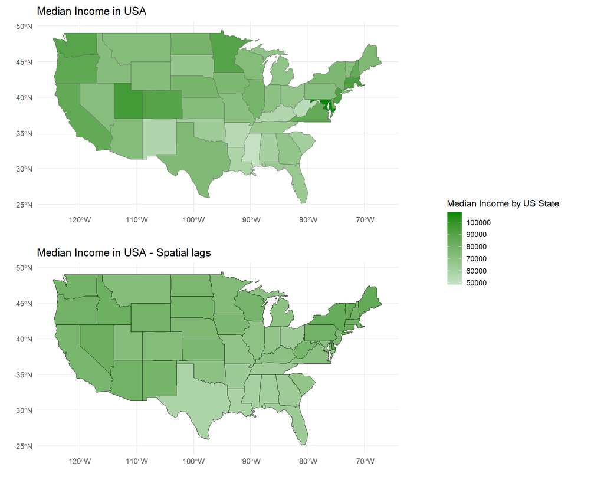

```r
plot1<- ggplot(income_data,aes(fill=median_income,
                       label=median_income)) +
  geom_sf()+
 #geom_sf_label(fun.geometry = sf::st_centroid,size=3,fill="white") +
  scale_fill_gradient(name = "Median Income by US State", low = "#C4E1C4", high = "#008802") +
  labs(title="Median Income in USA",
       x="",
       y="") +
  theme(plot.title = element_text(size=20,color="black"),
        legend.title = element_text(size=16,color="black"),
        legend.text = element_text(size=16,color="black"),
        legend.position = "bottom",
        plot.caption=element_text(size=16),
        text = element_text(family = "Times New Roman")) + theme_minimal()


legend <- get_legend(plot1)

plot2 <-income_lags %>%
  ggplot(aes(fill=income_lag)) +
  geom_sf(color="black",lwd=0.1) +
 #geom_sf_label(fun.geometry = sf::st_centroid,size=3,fill="white") +
  scale_fill_gradient(name = "Median Income by US State", low = "#C4E1C4", high = "#008802",limits= range(income_data$median_income)) +
  labs(title="Median Income in USA - Spatial lags",
       x="",
       y="") +
  theme(plot.title = element_text(size=20,color="black"),
        legend.title = element_text(size=16,color="black"),
        legend.text = element_text(size=16,color="black"),
        legend.position = "bottom",
        plot.caption=element_text(size=16),
        text = element_text(family = "Times New Roman")) + theme_minimal()


plot1 <- plot1 +theme(legend.position = "none")
plot2 <- plot2 +theme(legend.position = "none")


combined_plot <- plot_grid(plot1,plot2,ncol=1)

final_plot <- plot_grid(
  combined_plot,
  legend,
  ncol = 2,
  rel_widths = c(2,1))


print(final_plot)
```

## Creating a linear model WITHOUT special dependence

```r
income_data %>%
  as_tibble() %>%
  head()
```

```
## # A tibble: 6 × 9
##   id    name    density median_income urbanization population_density median_age
##   <chr> <chr>     <dbl>         <dbl>        <dbl>              <dbl>      <dbl>
## 1 01    Alabama    94.6         59910         57.7               99         39.5
## 2 04    Arizona    57.0         73450         89.3               62.9       38.5
## 3 05    Arkans…    56.4         53980         55.5               57.8       38.6
## 4 06    Califo…   242.          85300         94.2              254.        37.3
## 5 08    Colora…    49.3         89930         86                 55.7       37.3
## 6 09    Connec…   739.          90730         86.3              744.        41.2
## # ℹ 2 more variables: population_over_25 <dbl>, geometry <MULTIPOLYGON [°]>
```

```r
mod1 <- lm(data = income_data, formula = median_income ~ urbanization + population_density + median_age  + population_over_25)
```

```r
summary(mod1)
```

```
##
## Call:
## lm(formula = median_income ~ urbanization + population_density +
##     median_age + population_over_25, data = income_data)
##
## Residuals:
##      Min       1Q   Median       3Q      Max
## -12034.9  -3998.2   -224.1   4680.7   9475.4
##
## Coefficients:
##                     Estimate Std. Error t value Pr(>|t|)
## (Intercept)        40508.383  22852.251   1.773   0.0837 .
## urbanization         163.844     85.346   1.920   0.0619 .
## population_density    -3.362      5.196  -0.647   0.5212
## median_age          -897.568    496.323  -1.808   0.0779 .
## population_over_25  1678.694    179.019   9.377 9.36e-12 ***
## ---
## Signif. codes:  0 '***' 0.001 '**' 0.01 '*' 0.05 '.' 0.1 ' ' 1
##
## Residual standard error: 6049 on 41 degrees of freedom
## Multiple R-squared:  0.7928, Adjusted R-squared:  0.7725
## F-statistic: 39.21 on 4 and 41 DF,  p-value: 1.677e-13
```

#### Population density is highly insignifant so let’s remove this variable from the model

```r
mod1 <- lm(data = income_data, formula = median_income ~ urbanization + median_age  + population_over_25)
```

```r
summary(mod1)
```

```
##
## Call:
## lm(formula = median_income ~ urbanization + median_age + population_over_25,
##     data = income_data)
##
## Residuals:
##    Min     1Q Median     3Q    Max
## -11627  -4309   -302   3957   9014
##
## Coefficients:
##                    Estimate Std. Error t value Pr(>|t|)
## (Intercept)        49054.94   18518.74   2.649   0.0113 *
## urbanization         135.20      72.46   1.866   0.0691 .
## median_age         -1042.42     439.89  -2.370   0.0225 *
## population_over_25  1635.85     165.17   9.904 1.49e-12 ***
## ---
## Signif. codes:  0 '***' 0.001 '**' 0.01 '*' 0.05 '.' 0.1 ' ' 1
##
## Residual standard error: 6007 on 42 degrees of freedom
## Multiple R-squared:  0.7906, Adjusted R-squared:  0.7757
## F-statistic: 52.87 on 3 and 42 DF,  p-value: 2.579e-14
```

## Creating a linear model WITH spatial dependence

#### Moran test for regression residuals

#### H0: No spatial dependence in regression residuals

#### Since p-value < 0.05, it should be concluded that there exists a spatial dependence within linear regression’s residuals, which means that a spatial linear model would be better than “default” linear regression model

```r
lm.morantest(mod1,listw = nb2listw(nb))
```

```
##
##  Global Moran I for regression residuals
##
## data:
## model: lm(formula = median_income ~ urbanization + median_age +
## population_over_25, data = income_data)
## weights: nb2listw(nb)
##
## Moran I statistic standard deviate = 3.6711, p-value = 0.0001207
## alternative hypothesis: greater
## sample estimates:
## Observed Moran I      Expectation         Variance
##      0.306075659     -0.046455936      0.009221432
```

## Creating SAR spatial lag model

#### Formula

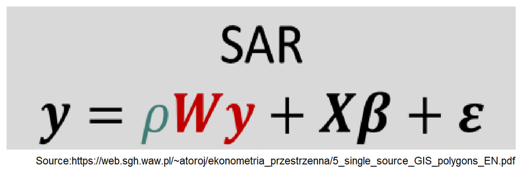

```r
ggplot() +
    background_image(readPNG("sar_formula.png")) +
  labs(caption = "Source:https://web.sgh.waw.pl/~atoroj/ekonometria_przestrzenna/5_single_source_GIS_polygons_EN.pdf")
```

##### The formula essentially means: Take the sum of multiplication of weights and Y values for each neighbor, scale with with Rho and add the X variables multiplied by their coefficients

```r
mod_spatial <- lagsarlm(formula = median_income ~ urbanization + median_age  + population_over_25,
    data = income_data,
    listw = nb2listw(nb))
```

```r
summary(mod_spatial,Nagelkerke = TRUE)
```

```
##
## Call:lagsarlm(formula = median_income ~ urbanization + median_age +
##     population_over_25, data = income_data, listw = nb2listw(nb))
##
## Residuals:
##       Min        1Q    Median        3Q       Max
## -13620.73  -3298.54    717.22   2787.88  11094.69
##
## Type: lag
## Coefficients: (numerical Hessian approximate standard errors)
##                     Estimate Std. Error z value  Pr(>|z|)
## (Intercept)        43918.717  16745.869  2.6227  0.008725
## urbanization         133.027     64.983  2.0471  0.040650
## median_age         -1277.523    406.908 -3.1396  0.001692
## population_over_25  1516.884    156.553  9.6893 < 2.2e-16
##
## Rho: 0.25099, LR test value: 5.0838, p-value: 0.024151
## Approximate (numerical Hessian) standard error: 0.10683
##     z-value: 2.3494, p-value: 0.018803
## Wald statistic: 5.5197, p-value: 0.018803
##
## Log likelihood: -460.871 for lag model
## ML residual variance (sigma squared): 29037000, (sigma: 5388.6)
## Nagelkerke pseudo-R-squared: 0.81255
## Number of observations: 46
## Number of parameters estimated: 6
## AIC: 933.74, (AIC for lm: 936.83)
```

#### All variables in the SAR model are significant.

## Direct and indirect effect

#### Due to the feedback loop (global spatial lag was used), it is needed to compute the direct (the impact of a particular variable on the Y variable in a particular neighbor) and the indirect effect (the impact of a particular variable in the neighbors of a particular neighbor on the Y value of that neighbor)

```r
impacts(mod_spatial,listw = nb2listw(nb))
```

```
## Impact measures (lag, exact):
##                        Direct   Indirect      Total
## urbanization         135.2303   42.37259   177.6029
## median_age         -1298.6870 -406.92602 -1705.6130
## population_over_25  1542.0131  483.16896  2025.1820
```

### Interpretation regarding the direct effect

#### If population_over_25 (% of people being at least 25 years old with a bachelor’s degree or higher) increases by 1 unit, median income will increase by 1542.0131

### Interpretation regarding the indirect effect

#### If urbanization increases by 1 unit, median income will increase by 42.37259 in neighboring units

#### If median_age increases by 1 unit, median income will decrease by -406.92602 in neighboring units

#### If population_over_25 (% of people being at least 25 years old with a bachelor’s degree or higher) increases by 1 unit, median income will increase by 483.16896 in neighboring units